# Stone2019

Michael McLaren

2019-08-25

## Setup

```r
library(here)
library(phyloseq)
library(tidyverse)
library(ggbeeswarm)
library(ggthemes)
library(cowplot)
# Custom functions and plot setup
source(here("analysis", "functions-and-ggplot-setup.R"))
```

## Import the data from Stone et al 2019

*The chunks in this section should only be evaluated once and so have `eval = FALSE`.*

Load the sample metadata + ASV table + ASV sequences for the canine samples.

```r
st <- read_csv(here("data", "stone2019-canine-asv-table.csv"),
    skip = 1)
sam <- readxl::read_excel(here("data", "stone2019-sample-data.xlsx"))
asvs <- Biostrings::readDNAStringSet(
    here("data", "stone2019-asv-sequences.fasta"))
sam %>%
    group_by(Cohort) %>%
    count
sam %>%
    filter(str_detect(Cohort, "Canine")) %>%
    count
```

Build a phyloseq object (it will contain just the canine samples).

```r
mat <- st %>%
    select(-1) %>%
    as("matrix")
rownames(mat) <- st %>% select(1) %>% deframe
samdf <- sam %>%
    select(-1) %>%
    as.data.frame
rownames(samdf) <- sam %>% select(1) %>% deframe
OTU <- otu_table(mat, taxa_are_rows = TRUE)
SAM <- sample_data(samdf)
ps.stone <- phyloseq(OTU, SAM, asvs)
ntaxa(ps.stone) == nrow(st) # All the taxa were successfully matched in OTU and asvs
nsamples(ps.stone) # All the canine samples were successfully imported
```

Everything looks good! Let’s add the read depth to the sample data, and save the phyloseq object, with only the ASVs that appear in the canine samples.

```r
sample_data(ps.stone)$Sample_sum = sample_sums(ps.stone)
saveRDS(ps.stone, here("results", "stone2019-ps.Rds"))
```

Note, only taxa that appear in at least one canine sample are included,

```r
taxa_sums(ps.stone) %>% min
```

## Compare ASVs in Stone2019 to our C. hiranonis ASVs

```r
ps <- readRDS(here("results", "ps.Rds"))
ps.stone <- readRDS(here("results", "stone2019-ps.Rds"))
hiranonis_seqs <- ps %>%
    subset_taxa(str_detect(NCBI_species, "hiranonis")) %>%
    refseq
```

Inspect the ASV sequence lengths in each dataset,

```r
refseq(ps) %>% as.character %>% nchar %>% table
```

```
## .
##  230  236  249  250  251  252  253  254  255  257  312
##   14    2    1    4   10 2275 7771  240   24    1    1
```

```r
refseq(ps.stone) %>% as.character %>% nchar %>% table
```

```
## .
## 215 230 231 232 233 234 259 268 281 293
##  30   2   1  83 617  12   1   1   1   1
```

The sequences of Stone2019 are shorter than ours, likely due to additional trimming of the ends of the amplicon sequences. So we will look for ASVs in their dataset that exactly match ASV4 and ASV62 in the overlapping region of ~233bp.

```r
asv4.stone <- Biostrings::whichPDict(refseq(ps.stone), hiranonis_seqs[["ASV4"]])
asv4.stone
```

```
## [1] 2
```

```r
asv62.stone <- Biostrings::whichPDict(refseq(ps.stone), hiranonis_seqs[["ASV62"]])
asv62.stone
```

```
## [1] 65
```

Note how similar the indices are of the ASVs in both datasets. This is likely a consequence of DADA2 ordering the ASVs by their abundance.

Are there any other ASVs close to ASV4 in their data?

```r
Biostrings::whichPDict(refseq(ps.stone), hiranonis_seqs[["ASV4"]],
    max.mismatch = 5, with.indels = TRUE)
```

```
## [1]  2 65
```

No, just these two.

Let’s name them so we can easily compare with our data.

```r
taxa_names(ps.stone)[asv4.stone] <- "ASV4"
taxa_names(ps.stone)[asv62.stone] <- "ASV62"
```

Does ASV62 always co-occur with ASV4?

```r
st <- otu_table(ps.stone) %>%
    t %>%
    prune_taxa(c("ASV4", "ASV62"), .) %>%
    as_tibble(tidy = FALSE)
head(st)
```

```
## # A tibble: 6 x 3
##   Sample   ASV4 ASV62
##   <chr>   <dbl> <dbl>
## 1 DGF0001  5812     0
## 2 DGF0005  3226     0
## 3 DGF0006     0     0
## 4 DGF0008  4920   793
## 5 DGF0011     0     0
## 6 DGF0012    19     0
```

```r
st %>%
    mutate_at(vars(ASV4, ASV62), ~ . > 0) %>%
    group_by(ASV4, ASV62) %>%
    count
```

```
## # A tibble: 3 x 3
## # Groups:   ASV4, ASV62 [3]
##   ASV4  ASV62     n
##   <lgl> <lgl> <int>
## 1 FALSE FALSE    28
## 2 TRUE  FALSE    28
## 3 TRUE  TRUE     20
```

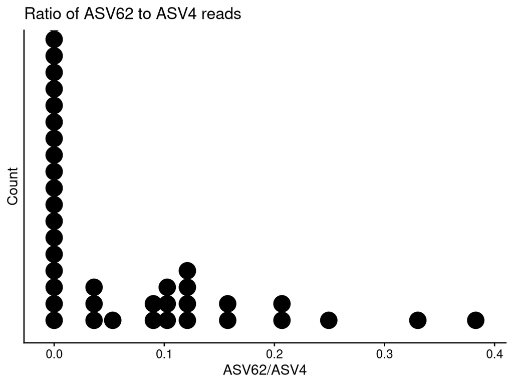

```r
st %>%
    filter(ASV4 > 0) %>%
    ggplot(aes(ASV62 / ASV4)) +
    geom_dotplot(stackgroups = TRUE, binpositions = "all", binwidth = 0.015) +
    scale_y_continuous(breaks = c()) +
    labs(y = "Count", title = "Ratio of ASV62 to ASV4 reads")
```

Just as in our data, ASV62 always occurs with and in a lower abundance than ASV4.

## C. difficile ASVs

Let’s also check for the C. difficile ASV82

```r
asv82.stone <- Biostrings::whichPDict(refseq(ps.stone), refseq(ps)[["ASV82"]])
asv82.stone
```

```
## [1] 68
```

```r
Biostrings::whichPDict(refseq(ps.stone), refseq(ps)[["ASV82"]],
    max.mismatch = 3, with.indels = TRUE) # No other C.diff ASVs
```

```
## [1] 68
```

```r
taxa_names(ps.stone)[asv82.stone] <- "ASV82"
# record the number of Cdiff reads
sample_data(ps.stone)$CD_reads <- prune_taxa("ASV82", otu_table(ps.stone)) %>%
    sample_sums
```

## Compare CD and CH detection by community 16S to other assays

Setup - create dataframes with the needed fields

```r
tb <- ps %>%
    subset_samples(Host_species == "Canine") %>%
    prune_taxa(c("ASV4", "ASV62"), .) %>%
    as_tibble(tax = FALSE) %>%
    spread(Taxon, Abundance) %>%
    mutate_if(~all(is.logical(.)), as.integer) %>%
    mutate(
        CD = CD_either,
        CH = factor((ASV4 > 0) + (ASV62 > 0))
    )
tb.stone <- ps.stone %>%
    prune_taxa(c("ASV4", "ASV62"), .) %>%
    as_tibble(tax = FALSE) %>%
    spread(Taxon, Abundance) %>%
    mutate_if(~all(is.logical(.)), as.integer) %>%
    mutate(
        CD_lab = C.difficile_Positive == "+",
        CD = CD_lab | (CD_reads > 0),
        CH = factor((ASV4 > 0) + (ASV62 > 0))
    )
```

### C. hiranonis

```r
tb.stone %>%
    transmute(
        CH_targeted = C..hiranonis_Detected == "+",
        CH_community = CH != 0,
        ) %>%
    table %>%
    addmargins
```

```
##            CH_community
## CH_targeted FALSE TRUE Sum
##       FALSE    27    0  27
##       TRUE      1   48  49
##       Sum      28   48  76
```

There is very close agreement from ASV read counts and detection by targeted sequencing.

### C. difficile

```r
tb.stone %>%
    transmute(
        CD_lab = C.difficile_Positive == "+",
        CD_reads = CD_reads > 0,
        ) %>%
    table %>%
    addmargins
```

```
##        CD_reads
## CD_lab  FALSE TRUE Sum
##   FALSE    39    0  39
##   TRUE     29    8  37
##   Sum      68    8  76
```

Community sequencing seems to be doing worse in detecting CD in the Stone dataset than what we observed, and does not detect any additional cases.

## Compare the effects of the two C. hiranonis strains on CD between datasets

```r
library(brms)
library(tidybayes)
```

Counts in our data:

```r
tb %>%
    select(CH, CD) %>%
    table %>%
    addmargins
```

```
##      CD
## CH    Negative Positive Sum
##   0         24       25  49
##   1         28        8  36
##   2         19        0  19
##   Sum       71       33 104
```

Counts in Stone2019 data:

```r
tb.stone %>%
    select(CH, CD) %>%
    table %>%
    addmargins
```

```
##      CD
## CH    FALSE TRUE Sum
##   0      11   17  28
##   1      18   10  28
##   2      10   10  20
##   Sum    39   37  76
```

Next, we estimate coefficients of CH1 and CH2 by Bayesian logistic regression.

```r
set.seed(42)
base_prior <- c(
    prior(student_t(7, 0, 1.53), class = Intercept),
    prior(student_t(7, 0, 1.77), class = b)
)
b1 <- brm(data = tb, family = bernoulli, CD ~ CH,
    prior = base_prior)
b1
```

```
##  Family: bernoulli
##   Links: mu = logit
## Formula: CD ~ CH
##    Data: tb (Number of observations: 104)
## Samples: 4 chains, each with iter = 2000; warmup = 1000; thin = 1;
##          total post-warmup samples = 4000
##
## Population-Level Effects:
##           Estimate Est.Error l-95% CI u-95% CI Eff.Sample Rhat
## Intercept    -0.03      0.28    -0.57     0.52       3710 1.00
## CH1          -1.18      0.47    -2.10    -0.29       2658 1.00
## CH2          -3.60      1.33    -6.87    -1.53       1594 1.00
##
## Samples were drawn using sampling(NUTS). For each parameter, Eff.Sample
## is a crude measure of effective sample size, and Rhat is the potential
## scale reduction factor on split chains (at convergence, Rhat = 1).
```

```r
b1.stone <- brm(data = tb.stone, family = bernoulli, CD ~ CH,
    prior = base_prior)
b1.stone
```

```
##  Family: bernoulli
##   Links: mu = logit
## Formula: CD ~ CH
##    Data: tb.stone (Number of observations: 76)
## Samples: 4 chains, each with iter = 2000; warmup = 1000; thin = 1;
##          total post-warmup samples = 4000
##
## Population-Level Effects:
##           Estimate Est.Error l-95% CI u-95% CI Eff.Sample Rhat
## Intercept     0.38      0.36    -0.31     1.10       2867 1.00
## CH1          -0.94      0.53    -1.97     0.08       3026 1.00
## CH2          -0.34      0.56    -1.46     0.74       2766 1.00
##
## Samples were drawn using sampling(NUTS). For each parameter, Eff.Sample
## is a crude measure of effective sample size, and Rhat is the potential
## scale reduction factor on split chains (at convergence, Rhat = 1).
```

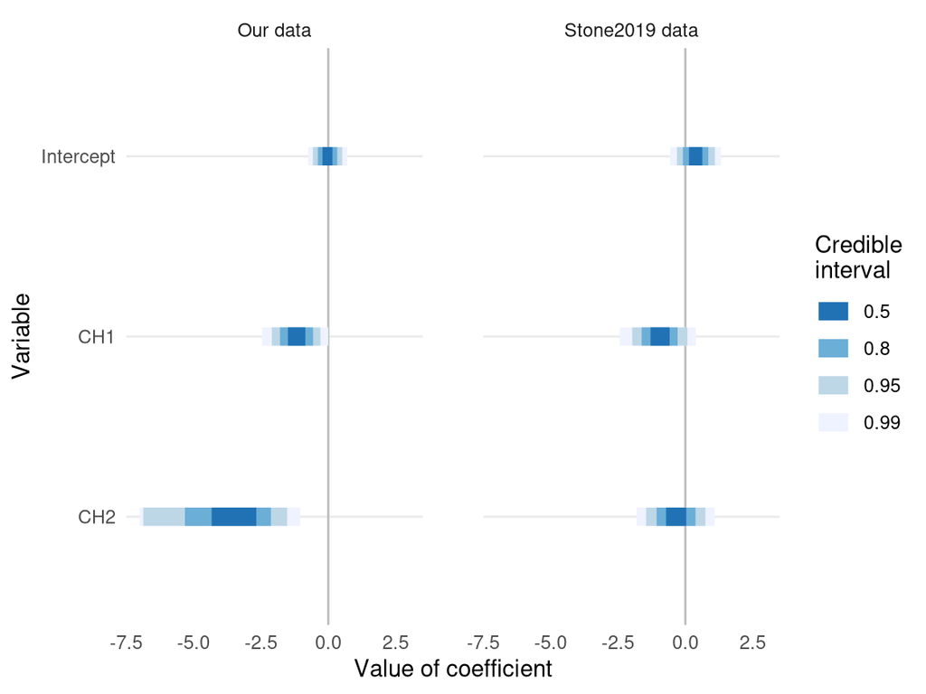

```r
lvls <- paste0("b_", c("Intercept", "CH1", "CH2"))
labeller <- function(lvl) {
    lvl %>%
        str_replace("b_", "") %>%
        str_replace("_", " ")
}
list(b1, b1.stone) %>%
    set_names(c("Our data", "Stone2019 data")) %>%
    map_dfr(gather_draws, `b_.+`, regex = TRUE, .id = "dataset") %>%
    ggplot(aes(y = factor(.variable, rev(lvls)), x = .value)) +
    geom_vline(xintercept = 0, color = "grey") +
    stat_intervalh(.width = c(.50, .80, .95, .99)) +
    scale_x_continuous(limits = c(-7, 3), oob = scales::squish) +
    scale_y_discrete(labels = labeller) +
    scale_color_brewer() +
    labs(y = "Variable", x = "Value of coefficient",
        color = "Credible\ninterval") +
    guides(colour = guide_legend(reverse = TRUE)) +
    theme_minimal() +
    facet_wrap(~dataset) +
    theme(panel.grid.major.x = element_blank(),
        panel.grid.minor.x = element_blank(),
        panel.spacing.x = unit(10, "mm"))
```

```r
ggsave(here("figures", "logreg-cd-stone2019.pdf"),
    width = 6, height = 2.5, units = "in")
```

The effect of CH1 are comparable in the two studies; but Stone2019 do not find the strong negative effect of CH2 that we observe; they also find a higher prevalance of CD in samples without C. hiranonis.